# sPLS regression

Hadrien Lorenzo

29 novembre 2018

*Ce TP est basé sur un document initialement rédigé par Boris Hejblum et repris par Robin Genuer.*

# Toxicité du paracétamol chez le rat

Charger `mixOmics` et les données correspondant à notre étude

```r
library(mixOmics)
data(liver.toxicity)
```

(Bushel, Wolfinger, and Gibson 2007)

Le sch?ma de l’étude est le suivant:

- Mesure de l’expression de 3116 gènes et de 10 variables biochimiques chez 64 rats (mâles)
- Les rats sont répartis en 3 groupes exposés à différentes doses d’acetaminophen (paracétamol) :
  - non toxique (50 or 150 mg/kg)
  - toxique (1500 mg/kg)
  - tr?s toxique (2000 mg/kg)
- Les prélèvements (dans le foie) ont eu lieu à 6, 18, 24 ou 48 heures après l’exposition.

## Travail demandé

On ne va considérer que le problème de régression. Il faut donc expliquer, pour les 64 rats, les 10 variables biochimiques en fonction des 3116 gènes, ou plutôt des gènes intéressants.

Pour celà on propose le protocole suivant :

- Tuner les différents param?tres de façon adequat afin de considérer un modèle précis.
- Commenter les performances de ce modèle et donner les représentations classiques de ce dernier :
  - Représentation des individus, discriminer visuellement les individus grâce aux conditions expérimentales (doses de paracétamol et dates de prélèvement).
  - Représentation des variables.
  - Utiliser une `cim` si le temps vous le permet.
- A chaque fois commenter les résultats obtenus.

Suivre ce protocole!

# Extraction des données

On standardise les données extraites

```r
X <- scale(liver.toxicity$gene) # On standardise les donn?es
y <- scale(liver.toxicity$clinic) # On standardise les donn?es
```

On regarde un peu leurs dimensions

```r
p <- ncol(X)
q <- ncol(y)
n <- nrow(y)
print(dim(X))
```

```
## [1]   64 3116
```

```r
print(dim(y))
```

```
## [1] 64 10
```

```r
print(getwd())
```

```
## [1] "C:/Users/hl1/Dropbox/cours_m2/spls_regression"
```

# Estimation des paramètres

On décide de faire une sPLS, car

- Il y a un grand nombre de variables, il faut donc en sélectionner cetaines.
- Les cliniciens veulent trouver du sens et de l’intérêt dans les gènes utilisés.

On décide de raliser la paramétrisation du modèle grâce à un leave-one-out, car

- Il y a un petit nombre de patients, il faut donc maximiser le nombre de `folds` (nombre de sous-échantillons dans la validation croisée)

Pour l’instant on ne fait de la sélection que selon **X**.

## Premiere composante

On cherche le $keep_X$ qui minimise l’erreur de prédiction moyenne sur la première composante.

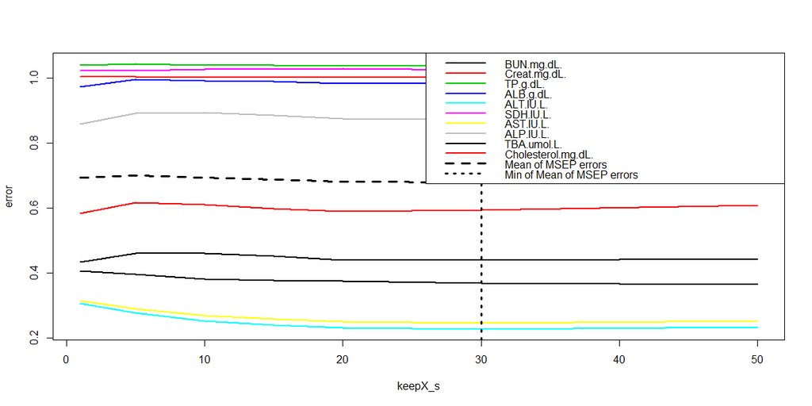

```r
keepX_s <- c(1,5,10,15,20,30,50)
error <- matrix(NA, length(keepX_s),q)
for(id in 1:length(keepX_s)){
  model <- spls(X,y,ncomp = 1,keepX = keepX_s[id],mode = "regression")
  res_validation_croisee <- perf(model, validation="loo")
  error[id,] <- res_validation_croisee$MSEP[,1]
}

matplot(keepX_s,error,type="l",lty=1,col=1:10,lwd=2)
points(keepX_s,rowMeans(error),lty=2,lwd=3,col=1,type="l")
abline(v=keepX_s[which(rowMeans(error)==min(rowMeans(error)))],lwd=3,lty=3)
legend("topright",
       legend = c(colnames(y),"Mean of MSEP errors","Min of Mean of MSEP errors"),
       col = c(1:10,1,1),lty =c(rep(1,10),2,3),lwd=c(rep(2,10),3,3))
```

Dans ce cas, il vient

$$keep_X^{(1)} = 30$$

pour une erreur de $0.6794462$.

## Deuxieme composante

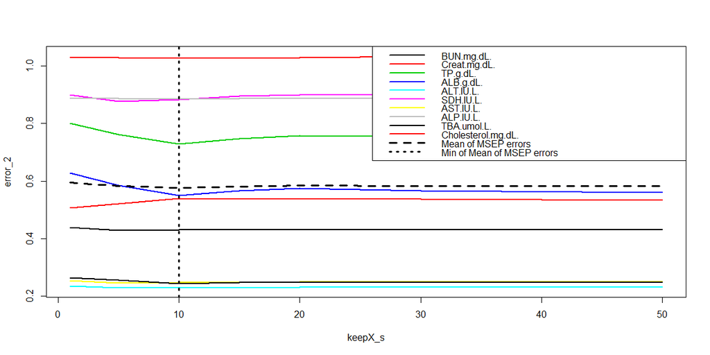

```r
keepx_1 <- 30
keepX_s <- c(1,5,10,15,20,30,50)
error_2 <- matrix(NA, length(keepX_s),q)
for(id in 1:length(keepX_s)){
  model <- spls(X,y,ncomp = 2,keepX = c(keepx_1,keepX_s[id]),mode = "regression")
  res_validation_croisee <- perf(model, validation="loo")
  error_2[id,] <- res_validation_croisee$MSEP[,2]
}

matplot(keepX_s,error_2,type="l",lty=1,col=1:10,lwd=2)
points(keepX_s,rowMeans(error_2),lty=2,lwd=3,col=1,type="l")
abline(v=keepX_s[which(rowMeans(error_2)==min(rowMeans(error_2)))],lwd=3,lty=3)
legend("topright",
       legend = c(colnames(y),"Mean of MSEP errors","Min of Mean of MSEP errors"),
       col = c(1:10,1,1),lty =c(rep(1,10),2,3),lwd=c(rep(2,10),3,3))
```

Dans ce cas, il vient

$$keep_X^{(2)} = 10$$
pour une erreur de $0.5778407$.

On voit bien que la seconde composante permet de prédire mieux la variable `TBA.umol.L.`. Il faut alors regarder l’évolution de l’erreur de prédiction entre un modèle à 1 composante et un modèle à 2 composantes :

$$error_{1\ comp} = 0.6794462,$$

$$error_{2\ comp} = 0.5778407.$$

Donc, deux cas peuvent se présenter à la construction d’une nouvelle composante, l’erreur peut:

- **augmenter** : c’est qu’il ne faut pas considérer la composante courante: On fait du surraprentissage. En plus celà implique nécessairement qu’il faut arrêter là la construction du modèle **PLS**.
- **diminuer** : alors la composante courante est à inclure dans le modèle. Il faut donc refaire le même travail pour la composante suivante.

On trouve les erreurs suivantes :

$$error_{3\ comp} = 0.5484291, \ error_{4\ comp} = 0.5311632,\ error_{5\ comp} = 0.5489561.$$

On voit bien que l’erreur réaugment à partir de la cinquièmee composante. Un choix raisonnable serait donc de ne conserver que $4$ composantes dans le modèle.

# Création du modèle à 2 composantes

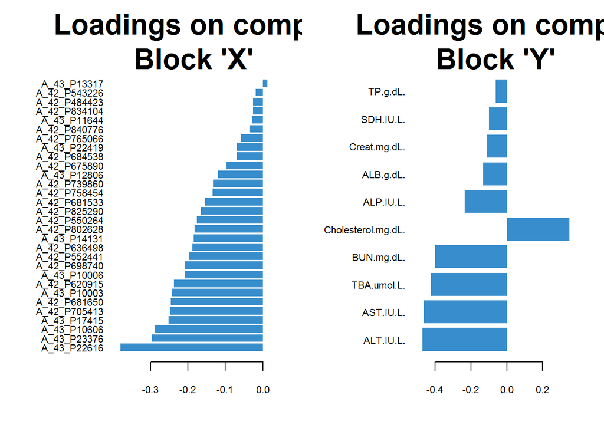

```r
model <- spls(X,y,ncomp=2,keepX = c(30,10))

plotLoadings(model, comp = 1, method = 'mean', contrib = 'max',legend=F)
```

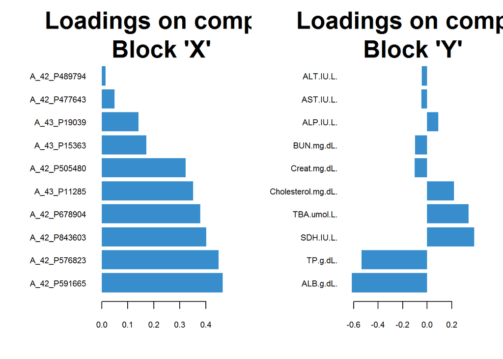

```r
plotLoadings(model, comp = 2, method = 'mean', contrib = 'max',legend=F)
```

On voit que les **Y** les mieux prédits par la première composante, **AST.IU.L.** et **ALT.IU.L.**, sont les deux variables les plus corrélées avec la première composante. Ce sont aussi les variables les moins corrélées avec la seconde composante.

## Interprétation des axes

### Par rapport à la dose administrée

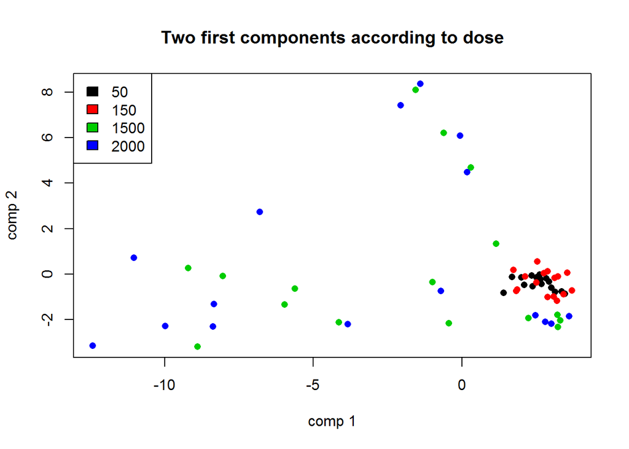

```r
Y_dose <- as.factor(liver.toxicity$treatment$Dose.Group)
plot(model$variates$X,col=Y_dose,pch=16,
     main="Two first components according to dose")
legend("topleft",legend=levels(Y_dose),fill = 1:4)
```

On voit très nettement ques les deux premières composantes sont très sensibles au niveau de dose.

### Par rapport au temps de prélèvement

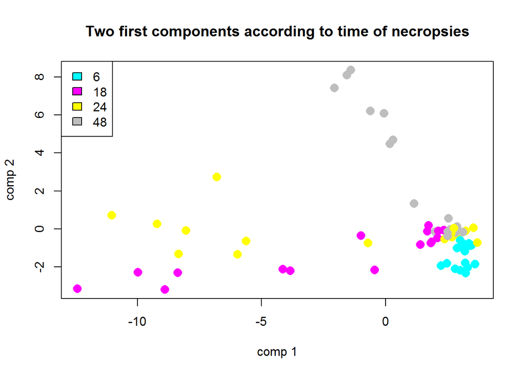

```r
Y_time <- as.factor(liver.toxicity$treatment$Time.Group)
plot(model$variates$X,col=as.numeric(Y_time)+4,pch=16,cex=1.5,
     main="Two first components according to time of necropsies")
legend("topleft",legend=levels(Y_time),fill = 1:4+4)
```

# References

Bushel, Pierre R, Russell D Wolfinger, and Greg Gibson. 2007. “Simultaneous Clustering of Gene Expression Data with Clinical Chemistry and Pathological Evaluations Reveals Phenotypic Prototypes.” *BMC Systems Biology* 1 (1). BioMed Central: 15.